# Real / Fake News Identification

Kaichong Zhang, Ling Ma, Yiming Miao

```r
library(stringr)
library(dplyr)
library(janeaustenr)
library(ngram)
library(stringr) #for regex
library(tidyverse)
library(tidytext)
library(glue)
```

```r
library(ggplot2)
library(caret)
library(randomForest)
library(gridExtra)
library(rpart)
library(infer)
library(reshape)
RNGversion("3.6.1")
```

## Part 0: Check the Data

```r
#Input the raw data
raw0 <- read.csv("https://www.macalester.edu/~ajohns24/data/buzzfeed.csv")
```

We first imported the original dataset, but found that there are many empty blanks. Therefore, we tried to fill them with N/A at firt, as that can be much more convenient to furthur process the data.

```r
#Input the raw data and fill the blanks with N/A
raw <- read.csv("https://www.macalester.edu/~ajohns24/data/buzzfeed.csv", header = T, na.strings = c("", " ", NA))
```

### General Information:

```r
#Check the dimension
dim(raw)
```

```
## [1] 182   6
```

```r
#Check the variables
colnames(raw)
```

```
## [1] "title"   "text"    "url"     "authors" "source"  "type"
```

```r
#Check the number of type
table(raw$type)
```

```
##
## fake real
##   91   91
```

```r
#Check the number of N/A in the title
sum(is.na(raw$title))
```

```
## [1] 0
```

```r
#Check the number of N/A in the text
sum(is.na(raw$text))
```

```
## [1] 0
```

```r
#Check the number of N/A in the url
sum(is.na(raw$url))
```

```
## [1] 8
```

```r
#Check the number of N/A in the author
sum(is.na(raw$authors))
```

```
## [1] 41
```

```r
#Check the number of N/A in the source
sum(is.na(raw$source))
```

```
## [1] 8
```

After checking some basic and general information, we found that this is not a quite large dataset. There are only 182 rows with 6 features: `title`, `text`, `url`, `authors`, `source`, `type`. And as we are trying to predict the authenticity of a given news, `type` is the label y here. Among these data, 91 of the news are `real`, whereas the other 91 are `fake`. The distribution is quite even here, which can be very helpful for further analysis. Also, we found that `url` and `source` both have 8 N/A cells, but the feature `authors` does have much information loss (41). For a small dataset of only 182 data, 41 can be a large proportion. To better decide how should we deal with them, we would like to get more details.

### More details about `source` and `authors`

```r
#Check the relationship between source and whether or not the news is real
do.call(rbind, lapply(levels(raw$source), FUN = function(x){
   tt <- subset(raw, source == x)
   result <- table(tt$type)
   result$source <- x
   return (result)
 }))
```

[output not shown]

```r
#Check the relationship between author and whether or not the news is real
do.call(rbind, lapply(levels(raw$authors), FUN = function(x){
   tt <- subset(raw, authors == x)
   result <- table(tt$type)
   result$authors <- x
   return (result)
 }))
```

[output not shown]

## Part 1: Process the data

We think that there are many underlying hints in `title` and `text` that indicate whether the news are real. Therefore, most of our predictors will focus on `title` and `text`.

### Create variables and data set

The codes below are the process we try to quantify `title` and `text`. Brief speaking, for title, we take the length, the number of exclamation marks, question marks, and capitalized words as fake news tend to include clickbait in a title. For text, we choose the length, number of quotations and proportion of sentiment words, because real news are usually longer, with more quotations and fewer sentiment words. Detailed codebook and reasons for choosing can be found below.

This is mainly a **human learning** process.

```r
#Create a variable that count the number of exclamation marks
TitleNumOfExc <- str_count(raw$title, "!")

#Create a variable that count the number of question marks
TitleNumOfQue <- str_count(raw$title, "\\?")

#Create a variable that count the number of capitalized words
TitleNumOfCap <- str_count(raw$title, "\\b[A-Z]{2,}\\b")

#Create a variable that count the length of the title
TitleLength <- str_count(raw$title, "\\W+")

#Create a variable that count the number of quotation marks
TextNumOfQuotation <- str_count(raw$text, "\"")

#Create a variable that count the length of text
TextLength <- str_count(raw$text, "\\W+")
```

```r
#Add the variables we create into a new data set
newsTemp <- raw %>%
  mutate(TitleNumOfExc) %>%
  mutate(TitleNumOfQue) %>%
  mutate(TitleNumOfCap) %>%
  mutate(TextNumOfQuotation) %>%
  mutate(TitleLength) %>%
  mutate(TextLength)

#Sentiment dictionary
temp <- tibble(txt = newsTemp$text) %>%
  mutate(txt = as.character(txt))

tokens <- temp %>%
  mutate(linenumber = row_number()) %>%
  unnest_tokens(word, txt)

#Get the sentiment from the first text:
tokens <- tokens %>%
  group_by(linenumber) %>%
  inner_join(get_sentiments("nrc")) %>% # pull out only sentiment words
  count(sentiment) %>% # count the # of positive & negative words
  spread(sentiment, n, fill = 0) # %>% # made data wide rather than narrow
#Combine two data frame together
newsTemp <- cbind(data.frame(newsTemp),data.frame(tokens))

#Get the portion of each sentiment among each text
newsTemp <- newsTemp %>%
  mutate(anger = anger/TextLength)  %>%
  mutate(anticipation = anticipation/TextLength)  %>%
  mutate(disgust = disgust/TextLength)  %>%
  mutate(fear = fear/TextLength)  %>%
  mutate(joy = joy/TextLength) %>%
  mutate(negative = negative/TextLength) %>%
  mutate(positive = positive/TextLength) %>%
  mutate(sadness = sadness/TextLength) %>%
  mutate(surprise = surprise/TextLength) %>%
  mutate(trust = trust/TextLength)
```

```r
#create the final dataset `newData` and remove unused variables.
newsData <- newsTemp %>%
  select(-title, -text, -url, -linenumber, -authors)
```

By manually examimg the data, we found that `url` is almost the same as `source`, and just provide a more specific website address. Therefore it couldn’t provide much information for us and will bring colinearties. `linenumber` is just a temporarily used variable in the sentiment dictionary code, so we need to remove it.

### Code book

| Variable name | Meaning |
| --- | --- |
| TitleNumOfExc | The number of exclamation mark in the title |
| TitleNumOfQue | The number of question mark in the title |
| TitleNumOfCap | The number of capitalized words in the title |
| TextNumOfQuotation | The number of quotation mark in the text |
| TitleLength | The length of the title |
| TextLength | The length of the text |
| anger | The proportion of anger expressions |
| anticipation | The proportion of anticipation expressions |
| disgust | The proportion of disgust expressions |
| fear | The proportion of fear expressions |
| joy | The proportion of joy expressions |
| negative | The proportion of negative expressions |
| positive | The proportion of positive expressions |
| sadness | The proportion of sadness expressions |
| surprise | The proportion of surprise expressions |
| trust | The proportion of trust expressions |

### Reasons of choosing

`TitleNumOfExc` and `TitleNumOfQue`: the number of exclamation marks and question marks can be important indicators because fake news tend to be more emotional or affecting, meaning that there will be more exclamation marks and question marks in the titles of fake news to attract readers.

`TitleNumOfCap`: the number of capitalized words is an important indicator because fake news usually tends to overemphasize some particular points they make, meaning that there will be more capitalized words in the titles of fake news.

`TextNumOfQuotation`: the number of quotation marks is an important indicator because real news tend to be more rigorous and having more quotations so that the content will be more reliable and verfiable, meaning that there will be fewer quotation marks in the text of fake news.

`TitleLength`: for fake news, the title tends to be longer because fake news tend to have more striking information in the title.

`TextLength`: for fake news, the text tends to be shorter because there are not many supporting evidence and it is hard for the fake news authors to talk a lot because they are talking about something doesn’t exist.

`anger`, `anticipation`, `disgust`, `fear`, `joy`, `negative`, `sadness`, `surprise` and `trust`: fake news tend to be more emotional and less objective, and therefore it might include more sentiment words/expression.

### Check human learning variable selection: real and fake news comparison

```r
#Set the seed
set.seed(253)

#Create a real news data set
realNews <- newsData %>%
  filter(type == "real")

#Create a fake news data set
fakeData <- newsData %>%
  filter(type == "fake")

#Pick a random real news
realNews[runif(1, min = 1, max = 81), ]
```

```
##              source type TitleNumOfExc TitleNumOfQue TitleNumOfCap
## 49 http://politi.co real             0             0             0
##    TextNumOfQuotation TitleLength TextLength     anger anticipation    disgust
## 49                  4           6        199 0.0201005   0.01005025 0.01507538
##          fear joy   negative   positive   sadness surprise      trust
## 49 0.03517588   0 0.03015075 0.03015075 0.0201005        0 0.01005025
```

```r
#Pick a random fake news
fakeData[runif(1, min = 1, max = 81), ]
```

```
##                     source type TitleNumOfExc TitleNumOfQue TitleNumOfCap
## 38 http://freedomdaily.com fake             0             0             0
##    TextNumOfQuotation TitleLength TextLength      anger anticipation    disgust
## 38                  0           8        330 0.02424242   0.01515152 0.02424242
##          fear        joy   negative   positive     sadness    surprise
## 38 0.01818182 0.01515152 0.03636364 0.08787879 0.006060606 0.006060606
##         trust
## 38 0.05454545
```

As a result, we summarize the mean of each variables for real news and fake news.

```r
#Summarize the mean of variables of different predictors of real news and fake news
newsDatagroup <- newsData %>%
  group_by(type) %>%
  summarize(mean(TitleNumOfExc), mean(TitleNumOfQue), mean(TitleNumOfCap),mean(TextNumOfQuotation), mean(TitleLength), mean(TextLength), mean(anger), mean(anticipation), mean(disgust), mean(fear), mean(joy), mean(negative), mean(positive), mean(sadness), mean(surprise), mean(trust))
newsDatagroup
```

```
## # A tibble: 2 × 17
##   type  `mean(TitleNumOfExc)` `mean(TitleNumO… `mean(TitleNumO… `mean(TextNumOf…
##   <chr>                 <dbl>            <dbl>            <dbl>            <dbl>
## 1 fake                 0.319            0.0879            1.01             0.308
## 2 real                 0.0330           0.0659            0.385            5.85
## # … with 12 more variables: mean(TitleLength) <dbl>, mean(TextLength) <dbl>,
## #   mean(anger) <dbl>, mean(anticipation) <dbl>, mean(disgust) <dbl>,
## #   mean(fear) <dbl>, mean(joy) <dbl>, mean(negative) <dbl>,
## #   mean(positive) <dbl>, mean(sadness) <dbl>, mean(surprise) <dbl>,
## #   mean(trust) <dbl>
```

However, although there are some mismatches, these variables are still useful, at least in **human learning**, in classifying fake news.

### Drawbacks

1. By focusing on each small features of the title or text, we might lose some “**human thinkings**” in the classification process. For example, some news, based on our classification predictors, look like fake news but they are actully real because the underlying information is so striking that the authors need exclamation mark to express this emotion.
2. Some sentiments we refer to might be overlapping with one another, meaning that the importance of these variables might be **overemphasized**. For example, sad words and negative words might be overlapping, so as joy words and positive words.
3. The amount of data is not big enough so that there might be some **variations** in the data that lead to the **unmatches** of our assumption with the data. Also, the low amount of data wil also lead to less accurate classification result.
4. Our predictors can only focus on some **particular features** of titles and texts, meaning that we can’t check the authenticity based on the more sophisticated **big picture** like themes and purposes of the news.

## Part 2: Analyze

Since this is a classification problem, we consider 4 algorithms: **Logistic Regression**, **KNN**, **Classification Tree**, and **Random Forest**.

These algorithms all have various pros and cons (shown in the table below), and at the current state, we have no idea which one will act better, so we are going to run all four models first.

| Model | Pros | Cons |
| --- | --- | --- |
| Logistic Regression | efficient; highly interpretable | a linear model in essence |
| KNN | nonparametric, flexible | computationally expensive; hard to interprete |
| Classification tree | computationally efficient | greedy, local |
| Random Forest | ensamble learning: reduce raviance & improve classification | cannot be visualized |

### With `Source`

We first try to use all available predictors in `newsData` (including `Source`) on these models.

#### Logistic Regression Model

```r
# Set the seed
set.seed(253)

# Run the model
logistic_model <- train(
    type ~ .,
    data = newsData,
    method = "glm",
    family = "binomial",
    trControl = trainControl(method = "cv", number = 5),
    metric = "Accuracy",
    na.action = na.omit
)
```

```r
summary(logistic_model)
```

```
##
## Call:
## NULL
##
## Deviance Residuals:
##     Min       1Q   Median       3Q      Max
## -1.7516  -0.2042   0.0000   0.0000   2.3088
##
## Coefficients:
##                                              Estimate Std. Error z value
## (Intercept)                                -2.462e+01  1.431e+05   0.000
## `sourcehttp://abcn.ws`                      2.238e+02  1.506e+05   0.001
## `sourcehttp://addictinginfo.org`            2.639e+01  1.431e+05   0.000
## `sourcehttp://allenwestrepublic.com`        4.808e-01  2.009e+05   0.000
## `sourcehttp://author.addictinginfo.org`     1.713e+00  2.591e+05   0.000
## `sourcehttp://author.groopspeak.com`       -1.689e+00  2.591e+05   0.000
## `sourcehttp://clashdaily.com`               5.116e-01  2.088e+05   0.000
## `sourcehttp://cnn.it`                       4.129e+02  1.563e+05   0.003
## `sourcehttp://conservativebyte.com`         2.378e+01  1.431e+05   0.000
## `sourcehttp://conservativetribune.com`      4.460e-01  2.033e+05   0.000
## `sourcehttp://eaglerising.com`              2.652e+01  1.431e+05   0.000
## `sourcehttp://freedomdaily.com`             2.332e+01  1.431e+05   0.000
## `sourcehttp://occupydemocrats.com`          2.288e+01  1.431e+05   0.000
## `sourcehttp://politi.co`                    3.078e+02  1.493e+05   0.002
## `sourcehttp://rightwingnews.com`            2.598e+01  1.431e+05   0.000
## `sourcehttp://theblacksphere.net`          -1.224e+00  2.074e+05   0.000
## `sourcehttp://usherald.com`                 9.655e+00  1.781e+05   0.000
## `sourcehttp://winningdemocrats.com`         2.708e+01  1.431e+05   0.000
## `sourcehttp://www.addictinginfo.org`        2.653e+01  1.431e+05   0.000
## `sourcehttp://www.chicksontheright.com`     3.342e+00  2.591e+05   0.000
## `sourcehttp://www.ifyouonlynews.com`        5.183e+01  1.970e+05   0.000
## `sourcehttp://www.opposingviews.com`        1.131e+02  2.593e+05   0.000
## `sourcehttp://www.proudcons.com`           -2.510e+01  2.093e+05   0.000
## `sourcehttp://www.thepoliticalinsider.com` -1.124e+00  1.731e+05   0.000
## `sourcehttp://www.yesimright.com`           1.181e+00  2.591e+05   0.000
## `sourcehttps://goo.gl`                      4.322e-01  1.834e+05   0.000
## `sourcehttps://ihavethetruth.com`          -2.888e+00  1.933e+05   0.000
## `sourcehttps://www.washingtonpost.com`      4.880e+01  2.591e+05   0.000
## TitleNumOfExc                              -1.615e+00  9.268e-01  -1.743
## TitleNumOfQue                               1.546e-01  1.300e+00   0.119
```

[output cut: 54 more lines]

```
## negative                                     0.1366
## positive                                     0.2863
## sadness                                      0.2164
## surprise                                     0.5061
## trust                                        0.0542 .
## ---
## Signif. codes:  0 '***' 0.001 '**' 0.01 '*' 0.05 '.' 0.1 ' ' 1
##
## (Dispersion parameter for binomial family taken to be 1)
##
##     Null deviance: 240.847  on 173  degrees of freedom
## Residual deviance:  58.779  on 130  degrees of freedom
## AIC: 146.78
##
## Number of Fisher Scoring iterations: 24
```

```r
set.seed(253)

# We can only make predictions for cases with information on the predictor
predict_data <- na.omit(logistic_model$trainingData)

# CLASSIFY each case in the sydney data set (using a 0.5 probability threshold)
classifications <- predict(logistic_model, newdata = predict_data, type = "raw")

# Construct a confusion matrix
confusionMatrix(data = classifications,
  reference = as.factor(predict_data$.outcome),
  positive = "real")
```

```
## Confusion Matrix and Statistics
##
##           Reference
## Prediction fake real
##       fake   78    9
##       real    5   82
##
##                Accuracy : 0.9195
##                  95% CI : (0.8687, 0.9553)
##     No Information Rate : 0.523
##     P-Value [Acc > NIR] : <2e-16
##
##                   Kappa : 0.8391
##
##  Mcnemar's Test P-Value : 0.4227
##
##             Sensitivity : 0.9011
##             Specificity : 0.9398
##          Pos Pred Value : 0.9425
##          Neg Pred Value : 0.8966
##              Prevalence : 0.5230
##          Detection Rate : 0.4713
##    Detection Prevalence : 0.5000
##       Balanced Accuracy : 0.9204
##
##        'Positive' Class : real
##
```

The in-sample accuracy is higher than the CV accuracy by around 0.10, which could be caused by the smal sample size.

```r
logistic_model$results
```

```
##   parameter  Accuracy     Kappa AccuracySD   KappaSD
## 1      none 0.8097479 0.6205563 0.06270957 0.1244459
```

#### KNN

```r
#KNN
set.seed(253)

knn_model <- train(
  type ~.,
  data = newsData,
  preProcess = c("center","scale"),
  method = "knn",
  tuneGrid = data.frame(k = c(seq(1, 182, by = 10), 182)),
  trControl = trainControl(method = "cv", number = 5, selectionFunction = "best"),
  metric = "Accuracy",
  na.action = na.omit
)
```

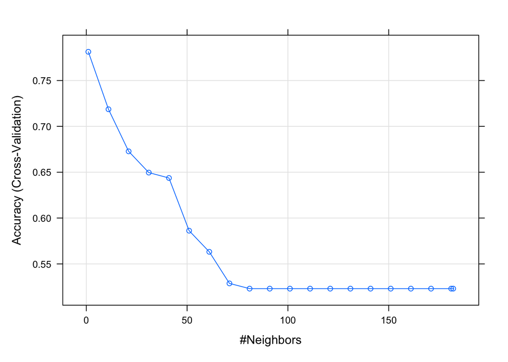

```r
plot(knn_model)
```

```r
knn_model$bestTune
```

```
##   k
## 1 1
```

```r
set.seed(253)

# We can only make predictions for cases with information on the predictor
predict_data <- na.omit(knn_model$trainingData)

# CLASSIFY each case in the sydney data set (using a 0.5 probability threshold)
classifications <- predict(knn_model, newdata = predict_data, type = "raw")

# Construct a confusion matrix
confusionMatrix(data = classifications,
  reference = as.factor(predict_data$.outcome),
  positive = "real")
```

```
## Confusion Matrix and Statistics
##
##           Reference
## Prediction fake real
##       fake   83    0
##       real    0   91
##
##                Accuracy : 1
##                  95% CI : (0.979, 1)
##     No Information Rate : 0.523
##     P-Value [Acc > NIR] : < 2.2e-16
##
##                   Kappa : 1
##
##  Mcnemar's Test P-Value : NA
##
##             Sensitivity : 1.000
##             Specificity : 1.000
##          Pos Pred Value : 1.000
##          Neg Pred Value : 1.000
##              Prevalence : 0.523
##          Detection Rate : 0.523
##    Detection Prevalence : 0.523
##       Balanced Accuracy : 1.000
##
##        'Positive' Class : real
##
```

It’s **very surprising*** to find the best tuned k is 1 and the in-sample accuracy is 1, which means the highest accuracy is achieved by only looking at one nearest neighbor and this did avoid any in-sample error.

```r
mean(knn_model$resample$Accuracy)
```

```
## [1] 0.7813445
```

#### Classification Tree

For the Classification Tree model, we use complexity parameter (cp) to get trees with differnt sizes. Similarly, we use cross validation to evaluate the best one.

```r
set.seed(253)
# Construct trees
tree_model <- train(
  type ~ .,
  data = newsData,
  method = "rpart",
  tuneGrid = data.frame(cp = seq(0,0.5,length=70)),
  trControl = trainControl(method = "cv", number = 10, selectionFunction = "oneSE"),
  metric = "Accuracy",
  na.action = na.omit
)
```

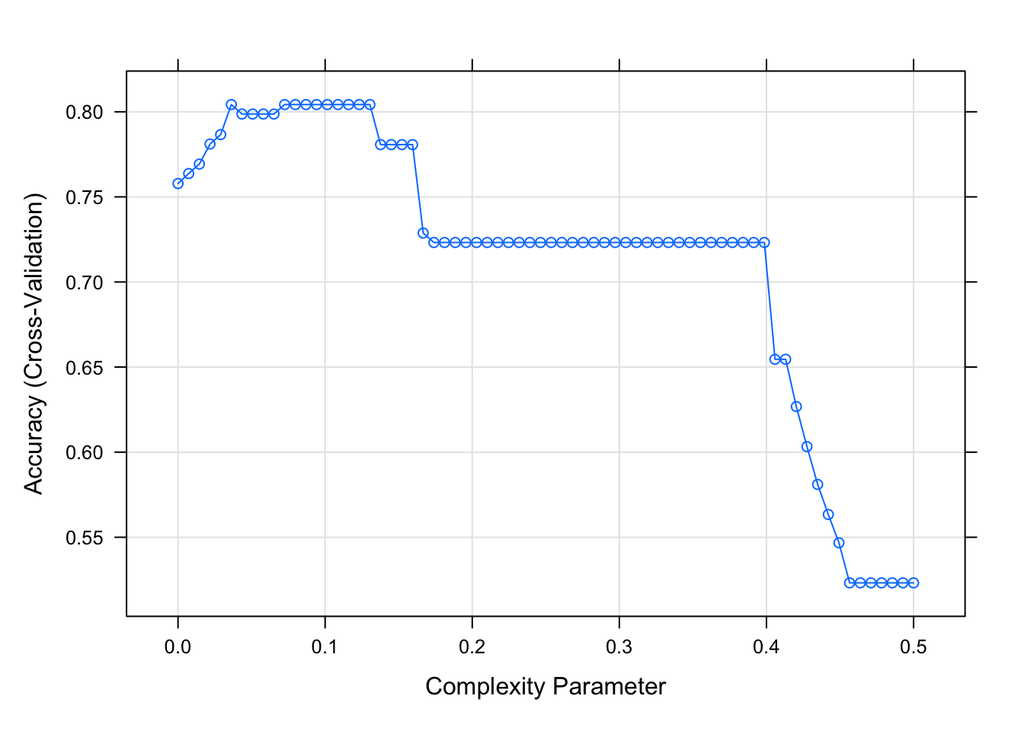

```r
plot(tree_model)
```

```r
tree_model$bestTune
```

```
##           cp
## 23 0.1594203
```

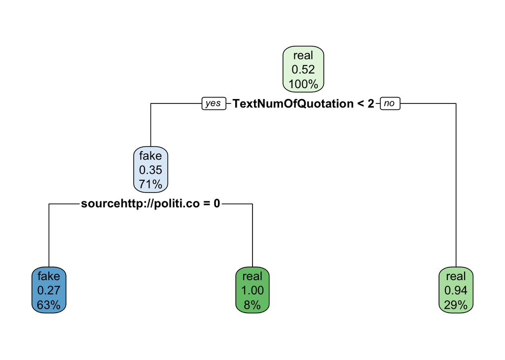

```r
# Plot the tree
library(rpart.plot)
rpart.plot(tree_model$finalModel)
```

```r
# Get metrics of variable importance
tree_model$finalModel$variable.importance
```

```
##     TextNumOfQuotation sourcehttp://politi.co    sourcehttp://cnn.it
##             24.4018984             15.0899818              8.2966455
##             TextLength   sourcehttp://abcn.ws            TitleLength
##              4.7297416              3.4162658              0.9760759
```

Looking at the best-prunned tree, we found that only two predictors are used here: `TextNumOfQuotation` (the number of quotation marks in the text), and a specific real news website `"politi.co"`.

```r
set.seed(253)

# We can only make predictions for cases with information on the predictor
predict_data <- na.omit(tree_model$trainingData)

# CLASSIFY each case in the sydney data set (using a 0.5 probability threshold)
classifications <- predict(tree_model, newdata = predict_data, type = "raw")

# Construct a confusion matrix
confusionMatrix(data = classifications,
  reference = as.factor(predict_data$.outcome),
  positive = "real")
```

```
## Confusion Matrix and Statistics
##
##           Reference
## Prediction fake real
##       fake   80   30
##       real    3   61
##
##                Accuracy : 0.8103
##                  95% CI : (0.7441, 0.8657)
##     No Information Rate : 0.523
##     P-Value [Acc > NIR] : 2.604e-15
##
##                   Kappa : 0.6252
##
##  Mcnemar's Test P-Value : 6.011e-06
##
##             Sensitivity : 0.6703
##             Specificity : 0.9639
##          Pos Pred Value : 0.9531
##          Neg Pred Value : 0.7273
##              Prevalence : 0.5230
##          Detection Rate : 0.3506
##    Detection Prevalence : 0.3678
##       Balanced Accuracy : 0.8171
##
##        'Positive' Class : real
##
```

```r
mean(tree_model$resample$Accuracy)
```

```
## [1] 0.780719
```

Here, we gain the in-sample accuracy of 0.8103 and CV accuracy of 0.780719, which are quite close.

An interesting distinction is between sensitivity (0.6703) and specificity (0.9639). This model tends to classify real news as fake, but can correctly classify fake as fake. Considering the sample size of real and fake are the same, it might because the features we get in the best tree are not quite great predictors for real news.